# DSI Breast Cancer - EDA and Predictive Analysis

Author: John Koenig

Date: 16JUN2021

```python
import os
import warnings

import pandas as pd
import numpy as np
import matplotlib.pyplot as plt
import matplotlib.lines as mlines
import seaborn as sns;

from sklearn.model_selection import train_test_split
from sklearn.preprocessing import MinMaxScaler
from sklearn.decomposition import PCA
from sklearn.ensemble import RandomForestClassifier
from sklearn import metrics
from dtreeviz.trees import dtreeviz, tree
from sklearn.model_selection import KFold

warnings.filterwarnings("ignore")  # supress DataConversionWarning
```

I did some search for optimal hyperparameters

```python
# hyperparameter grid search options
n_trees = 1000
decimals = 4
samples_percent_options = [s/100 for s in range(5, 100, 5)] + [.99]
depth_options = list(range(1,21))
```

Downloaded the data and cleaned it up

```python
url = r'https://gist.githubusercontent.com/jeff-boykin/b5c536467c30d66ab97cd1f5c9a3497d/raw/5233c792af49c9b78f20c35d5cd729e1307a7df7/breast-cancer.csv'
df = pd.read_csv(url, header=None)

# create column labels
input_variables_labels = ['var' + str(i) for i in range(len(df.columns) - 2)]
column_labels = ['patient_ID', 'target'] + input_variables_labels
df.columns = column_labels

# recode target column as 1/0
df['target'] = df['target'].str.contains('M').astype(int)

# extract input variable labels
df_columns = list(df.columns)
input_variables_labels = df_columns[2:]
input_variables = df.iloc[:,2:]
target = pd.DataFrame(df['target'])
patient_IDs = pd.DataFrame(df['patient_ID'])


df.head(10)
```

|  | patient_ID | target | var0 | var1 | var2 | var3 | var4 | var5 | var6 | var7 | ... | var20 | var21 | var22 | var23 | var24 | var25 | var26 | var27 | var28 | var29 |
| --- | --- | --- | --- | --- | --- | --- | --- | --- | --- | --- | --- | --- | --- | --- | --- | --- | --- | --- | --- | --- | --- |
| 0 | 842302 | 1 | 17.99 | 10.38 | 122.80 | 1001.0 | 0.11840 | 0.27760 | 0.30010 | 0.14710 | ... | 25.38 | 17.33 | 184.60 | 2019.0 | 0.1622 | 0.6656 | 0.7119 | 0.2654 | 0.4601 | 0.11890 |
| 1 | 842517 | 1 | 20.57 | 17.77 | 132.90 | 1326.0 | 0.08474 | 0.07864 | 0.08690 | 0.07017 | ... | 24.99 | 23.41 | 158.80 | 1956.0 | 0.1238 | 0.1866 | 0.2416 | 0.1860 | 0.2750 | 0.08902 |
| 2 | 84300903 | 1 | 19.69 | 21.25 | 130.00 | 1203.0 | 0.10960 | 0.15990 | 0.19740 | 0.12790 | ... | 23.57 | 25.53 | 152.50 | 1709.0 | 0.1444 | 0.4245 | 0.4504 | 0.2430 | 0.3613 | 0.08758 |
| 3 | 84348301 | 1 | 11.42 | 20.38 | 77.58 | 386.1 | 0.14250 | 0.28390 | 0.24140 | 0.10520 | ... | 14.91 | 26.50 | 98.87 | 567.7 | 0.2098 | 0.8663 | 0.6869 | 0.2575 | 0.6638 | 0.17300 |
| 4 | 84358402 | 1 | 20.29 | 14.34 | 135.10 | 1297.0 | 0.10030 | 0.13280 | 0.19800 | 0.10430 | ... | 22.54 | 16.67 | 152.20 | 1575.0 | 0.1374 | 0.2050 | 0.4000 | 0.1625 | 0.2364 | 0.07678 |
| 5 | 843786 | 1 | 12.45 | 15.70 | 82.57 | 477.1 | 0.12780 | 0.17000 | 0.15780 | 0.08089 | ... | 15.47 | 23.75 | 103.40 | 741.6 | 0.1791 | 0.5249 | 0.5355 | 0.1741 | 0.3985 | 0.12440 |
| 6 | 844359 | 1 | 18.25 | 19.98 | 119.60 | 1040.0 | 0.09463 | 0.10900 | 0.11270 | 0.07400 | ... | 22.88 | 27.66 | 153.20 | 1606.0 | 0.1442 | 0.2576 | 0.3784 | 0.1932 | 0.3063 | 0.08368 |
| 7 | 84458202 | 1 | 13.71 | 20.83 | 90.20 | 577.9 | 0.11890 | 0.16450 | 0.09366 | 0.05985 | ... | 17.06 | 28.14 | 110.60 | 897.0 | 0.1654 | 0.3682 | 0.2678 | 0.1556 | 0.3196 | 0.11510 |
| 8 | 844981 | 1 | 13.00 | 21.82 | 87.50 | 519.8 | 0.12730 | 0.19320 | 0.18590 | 0.09353 | ... | 15.49 | 30.73 | 106.20 | 739.3 | 0.1703 | 0.5401 | 0.5390 | 0.2060 | 0.4378 | 0.10720 |
| 9 | 84501001 | 1 | 12.46 | 24.04 | 83.97 | 475.9 | 0.11860 | 0.23960 | 0.22730 | 0.08543 | ... | 15.09 | 40.68 | 97.65 | 711.4 | 0.1853 | 1.0580 | 1.1050 | 0.2210 | 0.4366 | 0.20750 |

10 rows × 32 columns

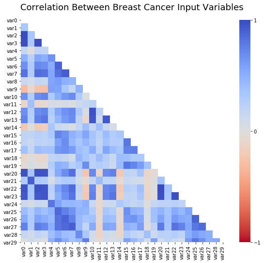

```python
# create mask for upper right of triangle
mask = np.triu(np.ones_like(input_variables.corr(), dtype=bool))

# create correlation heatmap for input variables
corr_min = -1
corr_max = 1

fig, ax = plt.subplots(figsize=(9.5, 8))

sns.heatmap(input_variables.corr(),
            vmin=corr_min,
            vmax=corr_max,
            cmap='coolwarm_r',
            cbar_kws={"ticks": [-1, 0, 1]},
            mask=mask,
            ax=ax)

fig.suptitle('Correlation Between Breast Cancer Input Variables', x=.46, fontsize=18)

plt.subplots_adjust(top=.92)
plt.show()
```

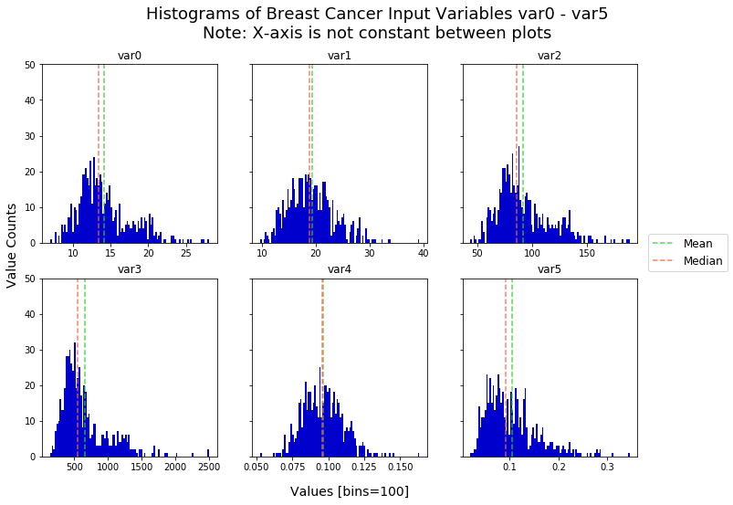

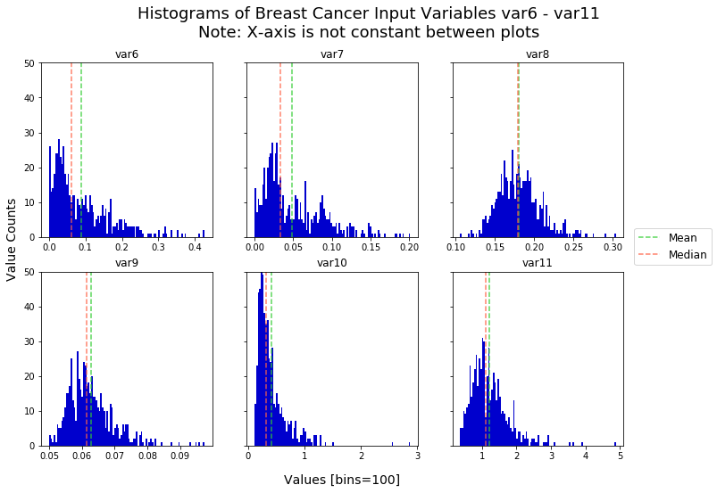

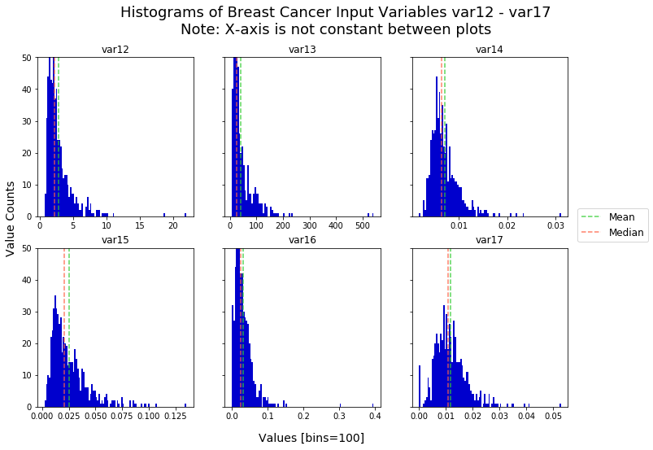

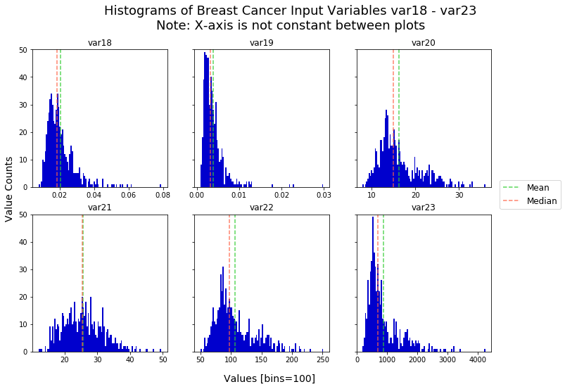

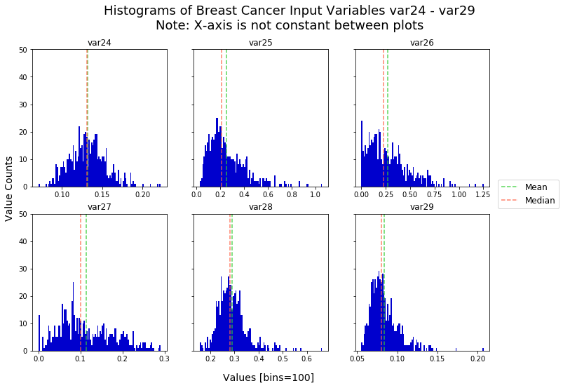

```python
# create a histogram for each variable
axes_per_fig = 6

bins = 100
x_limit = (0, 5000)
y_limit = (0, 50)
hist_color = 'mediumblue'

# iterate over input variables and create custom histograms for each
for p in range(int(len(input_variables_labels) / axes_per_fig)):

    start_index = p * 6
    end_index = p * 6 + 6
    var_labels_tmp = input_variables_labels[start_index:end_index]

    fig, ax = plt.subplots(2, 3, figsize=(12, 8), sharey=True)

    ax_list = [ax[0,0], ax[0,1], ax[0,2], ax[1,0], ax[1,1], ax[1,2]]

    for i in range(len(ax_list)):
        ax_list[i].hist(input_variables[var_labels_tmp[i]], bins=bins, color=hist_color)
        ax_list[i].set_title(var_labels_tmp[i])
        ax_list[i].set_ylim(y_limit)

    suptitle = f'Histograms of Breast Cancer Input Variables {var_labels_tmp[0]} - {var_labels_tmp[5]}'
    suptitle += '\nNote: X-axis is not constant between plots'
    fig.suptitle(suptitle, x=.55, fontsize=18)
    fig.subplots_adjust(top=0.87)

    # add axis labels
    x_axis_label = f'Values [bins={bins}]'
    y_axis_label = f'Value Counts'
    fig.text(.44, .05, x_axis_label, fontsize=14)
    fig.text(.08, .45, y_axis_label, fontsize=14, rotation=90)

    # add vertical lines for mean/median
    lines_labels = ['Mean', 'Median']
    colors = ['limegreen', 'tomato']
    line_styles = ['--', '--']
    alpha = .8

    for i in range(len(ax_list)):
        mean_tmp = input_variables[var_labels_tmp[i]].mean()
        med_tmp = input_variables[var_labels_tmp[i]].median()

        ax_list[i].axvline(x=mean_tmp, color=colors[0], linestyle=line_styles[0], alpha=alpha)
        ax_list[i].axvline(x=med_tmp, color=colors[1], linestyle=line_styles[1], alpha=alpha)

    # create custom legend
    handles = [mlines.Line2D([], [], color=colors[0], linestyle=line_styles[0], alpha=alpha),
               mlines.Line2D([], [], color=colors[1], linestyle=line_styles[1], alpha=alpha)]

    fig.legend(handles, lines_labels, loc='right', fontsize=12)
    fig.subplots_adjust(right=.88)

    plt.show()
```

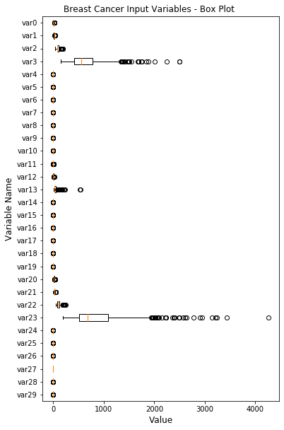

```python
# reshape input data
input_variables_labels_reversed = input_variables_labels[::-1]
box_input = input_variables[input_variables_labels_reversed].T

# create box plot
fig, ax = plt.subplots(figsize=(6, 10))

ax.boxplot(box_input, vert=False)

ax.set_yticklabels(input_variables_labels_reversed)
ax.set_title('Breast Cancer Input Variables - Box Plot', x=.45)
ax.set_xlabel('Value', fontsize=12)
ax.set_ylabel('Variable Name', fontsize=12)

plt.show()
```

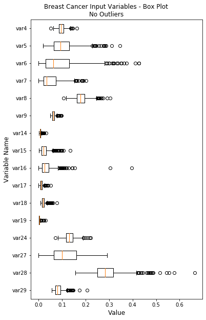

```python
# remove outliers
outlier_cutoff = 1
no_outliers_list = []

for v in input_variables_labels:
    if input_variables[v].max() <= outlier_cutoff:
        no_outliers_list.append(v)

input_variables_no_outliers = input_variables[no_outliers_list]

# reshape input data
input_variables_no_outliers_labels_reversed = input_variables_no_outliers.columns.to_list()[::-1]
box_input = input_variables[input_variables_no_outliers_labels_reversed].T

# create box plot
fig, ax = plt.subplots(figsize=(6, 10))

ax.boxplot(box_input, vert=False)

ax.set_yticklabels(input_variables_no_outliers_labels_reversed)
ax.set_title('Breast Cancer Input Variables - Box Plot\nNo Outliers', x=.44)
ax.set_xlabel('Value', fontsize=12)
ax.set_ylabel('Variable Name', fontsize=12)

plt.show()
```

I did a 75/25 split because I didn't have enough records for 3 partitions

```python
# Split Dataset for Training 75-25, StandardScaler and Conduct PCA

test_split = .25
n_components = 20
final_components = 3

scaled_columns = ['s_var' + str(c) for c in range(len(input_variables_labels))]
pca_columns = [f'pc{p}' for p in range(final_components)]

# split dataset into train/test partitions
x = pd.concat([patient_IDs, input_variables], axis=1)
y = target

x_train, x_test, y_train, y_test = train_test_split(x, y, test_size=test_split, stratify=y)

# save IDs
patient_IDs_train = x_train.iloc[:,0]
patient_IDs_test = x_test.iloc[:,0]

# drop ID column
x_train = x_train.iloc[:,1:]
x_test = x_test.iloc[:,1:]

# replace column labels
x_train.columns = [f's_{i}' for i in input_variables_labels]
x_test.columns = [f's_{i}' for i in input_variables_labels]
y_train = pd.DataFrame(y_train, index=x_train.index, columns=['target'])
y_test = pd.DataFrame(y_test, index=x_test.index, columns=['target'])

# scale input variables
scaler = MinMaxScaler()
scale_fit = scaler.fit(pd.concat([x_train,x_test], axis=0))
scaled_output_train = scale_fit.transform(x_train)
scaled_output_test = scale_fit.transform(x_test)
scaled_output_train = pd.DataFrame(scaled_output_train, index=x_train.index, columns=scaled_columns)
scaled_output_test = pd.DataFrame(scaled_output_test, index=x_test.index, columns=scaled_columns)

# conduct PCA
pca = PCA(n_components=n_components)

pca_model = pca.fit(x_train)
pca_variance = np.round(pca_model.explained_variance_ratio_, decimals=3) * 100
pca_variance_cum = np.cumsum(np.round(pca_model.explained_variance_ratio_, decimals=3) * 100)

# get eigenvalues
vars_covar = np.cov(x_train)
eigen_values, eigen_vectors = np.linalg.eig(vars_covar)
eigen_values = np.round(eigen_values.astype(float), 2)[:n_components]

# make predictions
pca_output_train = pca_model.transform(scaled_output_train)[:,:final_components]
pca_output_test = pca_model.transform(scaled_output_test)[:,:final_components]
pca_output_train = pd.DataFrame(pca_output_train, index=x_train.index, columns=pca_columns)
pca_output_test = pd.DataFrame(pca_output_test, index=x_test.index, columns=pca_columns)

pca_output = pd.concat([pca_output_train, pca_output_test], axis=0)
pca_output.index = range(len(pca_output))
```

|  | pc0 | pc1 | pc2 |
| --- | --- | --- | --- |
| 0 | -1107.116895 | -93.786128 | 34.985989 |
| 1 | -1107.660200 | -93.974318 | 34.968568 |
| 2 | -1107.719543 | -94.002454 | 34.995779 |
| 3 | -1107.684573 | -93.999981 | 34.986765 |
| 4 | -1107.612105 | -93.969676 | 34.981803 |

I am conducting my hyperparameter grid search here

```python
# Train Random Forest Model

# Create dataframe to store results
results_df_columns = ['model_name',
                      'train_test',
                      'test_split',
                      'total_records',
                      'n_trees',
                      'sample_percent',
                      'depth',
                      'true_positive',
                      'true_negative',
                      'false_positive',
                      'false_negative',
                      'true_positive_rate',
                      'true_negative_rate',
                      'false_positive_rate',
                      'false_negative_rate',
                      'accuracy',
                      'precision',
                      'recall',
                      'F1_score',
                      'ROC_area']

results_df = pd.DataFrame(columns=results_df_columns)

# conduct grid search
for samples in samples_percent_options:
    for depth in depth_options:

        model_name = f'RF_trees{n_trees}_sample{samples}_depth{depth}'

        # train random forest
        train_test = 'Train'

        x = pca_output_train
        y = y_train

        rf = RandomForestClassifier(n_estimators=n_trees,
                                    max_depth=depth,
                                    bootstrap=True,
                                    max_samples=samples)

        rf_model = rf.fit(x, y)
        rf_train_predict = rf.predict(x)

        # get confusion matrix and metrics for train partition
        confusion_matrix_train = metrics.confusion_matrix(rf_train_predict, y)

        total_records = len(x)

        true_positive = confusion_matrix_train[0,0]
        true_negative = confusion_matrix_train[1,1]
        false_positive = confusion_matrix_train[0,1]
        false_negative = confusion_matrix_train[1,0]

        true_positive_rate = np.round(true_positive / (true_positive + false_positive), decimals)
        true_negative_rate = np.round(true_negative / (true_negative + false_negative), decimals)
        false_positive_rate = np.round(false_positive / (true_positive + false_positive), decimals)
        false_negative_rate = np.round(false_negative / (true_negative + false_negative), decimals)

        accuracy = np.round((true_positive + false_negative) / total_records, decimals)
        precision = np.round(true_positive / (true_positive + false_positive), decimals)
        recall = np.round(true_positive / (true_positive + false_negative), decimals)
        F1_score = np.round(2 / ((1 / precision) + (1 / recall)), decimals)

        ROC_area = np.round(metrics.roc_auc_score(y_train, rf_train_predict), decimals)

        # save model training metrics
        results_df_tmp = pd.DataFrame([[model_name,
                                        train_test,
                                        test_split,
                                        total_records,
                                        n_trees,
                                        samples,
                                        depth,
                                        true_positive,
                                        true_negative,
                                        false_positive,
                                        false_negative,
                                        true_positive_rate,
                                        true_negative_rate,
                                        false_positive_rate,
                                        false_negative_rate,
                                        accuracy,
                                        precision,
                                        recall,
                                        F1_score,
                                        ROC_area]], columns=results_df_columns)

        results_df = pd.concat([results_df, results_df_tmp], axis=0)
        results_df.index = range(len(results_df))



        # test random forest
        train_test = 'Test'

        #print(f' Testing Model - {model_name}')

        # get predictions
        x = pca_output_test
        y = y_test

        rf_test_predict = rf_model.predict(x)

        # get confusion matrix and metrics for test partition
        confusion_matrix_train = metrics.confusion_matrix(rf_test_predict, y)

        total_records = len(x)

        true_positive = confusion_matrix_train[0,0]
        true_negative = confusion_matrix_train[1,1]
        false_positive = confusion_matrix_train[0,1]
        false_negative = confusion_matrix_train[1,0]

        true_positive_rate = np.round(true_positive / (true_positive + false_positive), decimals)
        true_negative_rate = np.round(true_negative / (true_negative + false_negative), decimals)
        false_positive_rate = np.round(false_positive / (true_positive + false_positive), decimals)
        false_negative_rate = np.round(false_negative / (true_negative + false_negative), decimals)

        accuracy = np.round((true_positive + false_negative) / total_records, decimals)
        precision = np.round(true_positive / (true_positive + false_positive), decimals)
        recall = np.round(true_positive / (true_positive + false_negative), decimals)
        F1_score = np.round(2 / ((1 / precision) + (1 / recall)), decimals)

        ROC_area = np.round(metrics.roc_auc_score(y_test, rf_test_predict), decimals)

        # save model test results
        results_series = pd.DataFrame([[model_name,
                                        train_test,
                                        test_split,
                                        total_records,
                                        n_trees,
                                        samples,
                                        depth,
                                        true_positive,
                                        true_negative,
                                        false_positive,
                                        false_negative,
                                        true_positive_rate,
                                        true_negative_rate,
                                        false_positive_rate,
                                        false_negative_rate,
                                        accuracy,
                                        precision,
                                        recall,
                                        F1_score,
                                        ROC_area]], columns=results_df_columns)

        results_df = pd.concat([results_df, results_series], axis=0)

results_df.index = range(len(results_df))
```

I am reprocessing the train/test results data so I can make heatmaps

```python
# Reshape Metrics Data

# prepare metrics
test_metrics_list = ['true_positive_rate',
                     'true_negative_rate',
                     'false_positive_rate',
                     'false_negative_rate',
                     'accuracy',
                     'precision',
                     'recall',
                     'F1_score',
                     'ROC_area']

samples_percent_columns = [str(d) for d in depth_options]
depth_index = [f'{str(int(s * 100))}%' for s in samples_percent_options]

# filter for only test records
results_df_test = results_df[results_df['train_test'] == 'Test']
results_df_test.sort_values(['sample_percent', 'depth'], inplace=True)
results_df_test.index = range(len(results_df_test))

# create metric dataframes
true_positive_rate_df = pd.DataFrame(columns=samples_percent_columns)
true_negative_rate_df = pd.DataFrame(columns=samples_percent_columns)
false_positive_rate_df = pd.DataFrame(columns=samples_percent_columns)
false_negative_rate_df = pd.DataFrame(columns=samples_percent_columns)
accuracy_df = pd.DataFrame(columns=samples_percent_columns)
precision_df = pd.DataFrame(columns=samples_percent_columns)
recall_df = pd.DataFrame(columns=samples_percent_columns)
F1_score_df = pd.DataFrame(columns=samples_percent_columns)
ROC_area_df = pd.DataFrame(columns=samples_percent_columns)

# iterate and build individual metrics dataframes
for samples in samples_percent_options:

    sample_df_tmp = results_df_test[results_df_test['sample_percent'] == samples]

    true_positive_rate_tmp = pd.DataFrame([sample_df_tmp['true_positive_rate'].values], columns=samples_percent_columns)
    true_positive_rate_df = pd.concat([true_positive_rate_df, true_positive_rate_tmp], axis=0)
    true_negative_rate_tmp = pd.DataFrame([sample_df_tmp['true_negative_rate'].values], columns=samples_percent_columns)
    true_negative_rate_df = pd.concat([true_negative_rate_df, true_negative_rate_tmp], axis=0)
    false_positive_rate_tmp = pd.DataFrame([sample_df_tmp['false_positive_rate'].values], columns=samples_percent_columns)
    false_positive_rate_df = pd.concat([false_positive_rate_df, false_positive_rate_tmp], axis=0)
    false_negative_rate_tmp = pd.DataFrame([sample_df_tmp['false_negative_rate'].values], columns=samples_percent_columns)
    false_negative_rate_df = pd.concat([false_negative_rate_df, false_negative_rate_tmp], axis=0)
    accuracy_tmp = pd.DataFrame([sample_df_tmp['accuracy'].values], columns=samples_percent_columns)
    accuracy_df = pd.concat([accuracy_df, accuracy_tmp], axis=0)
    precision_tmp = pd.DataFrame([sample_df_tmp['precision'].values], columns=samples_percent_columns)
    precision_df = pd.concat([precision_df, precision_tmp], axis=0)
    recall_tmp = pd.DataFrame([sample_df_tmp['recall'].values], columns=samples_percent_columns)
    recall_df = pd.concat([recall_df, recall_tmp], axis=0)
    F1_score_tmp = pd.DataFrame([sample_df_tmp['F1_score'].values], columns=samples_percent_columns)
    F1_score_df = pd.concat([F1_score_df, F1_score_tmp], axis=0)
    ROC_area_tmp = pd.DataFrame([sample_df_tmp['ROC_area'].values], columns=samples_percent_columns)
    ROC_area_df = pd.concat([ROC_area_df, ROC_area_tmp], axis=0)

# set indexes of metrics dataframes
true_positive_rate_df.index = depth_index
true_negative_rate_df.index = depth_index
false_positive_rate_df.index = depth_index
false_negative_rate_df.index = depth_index
accuracy_df.index = depth_index
precision_df.index = depth_index
recall_df.index = depth_index
F1_score_df.index = depth_index
ROC_area_df.index = depth_index
```

I made a confusion matrix with heatmaps (representing the grid search), additional heatmaps for other metrics are on the right side of the plot

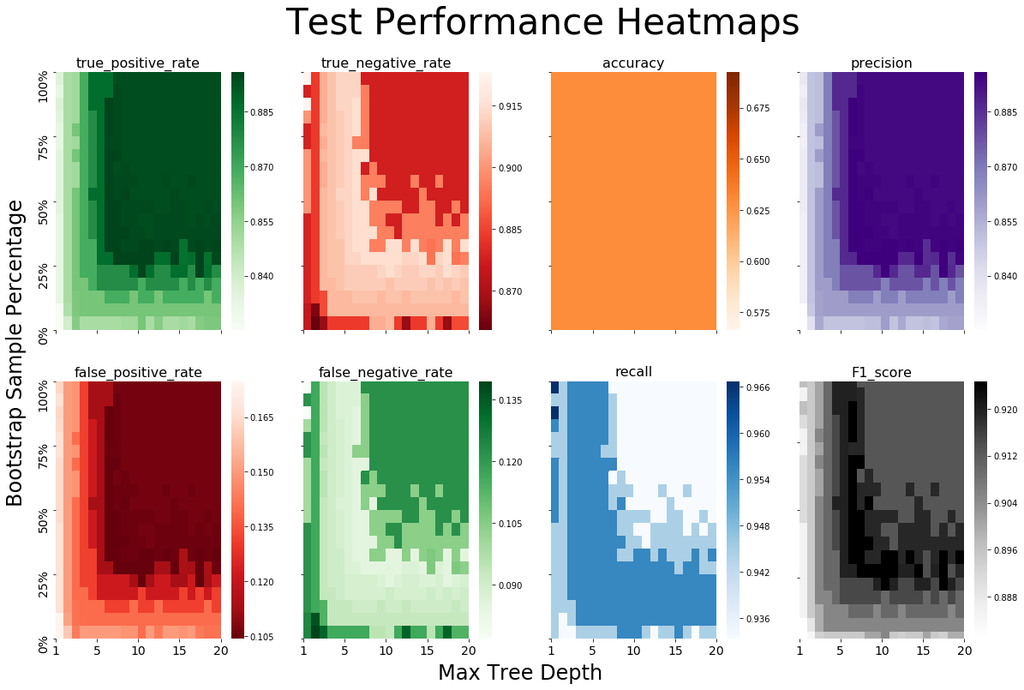

```python
# Create Heatmap Multiplots

x_ticks = [0, 5, 10, 15, 20]
x_tick_labels = ['1', '5', '10', '15', '20']
y_ticks = [0, 5, 10, 15, 20]
y_tick_labels = ['0%', '25%', '50%', '75%', '100%']
x_axis_label = 'Max Tree Depth'
y_axis_label = 'Bootstrap Sample Percentage'

y_tick_labels.reverse()

fig, ax = plt.subplots(2, 4, figsize=(20, 12), sharex=True, sharey=True)
fig.suptitle('Test Performance Heatmaps', x=.525, fontsize=42)

sns.heatmap(np.flip(true_positive_rate_df.values, 0), cmap='Greens', ax=ax[0,0])
sns.heatmap(np.flip(true_negative_rate_df.values, 0), cmap='Reds_r', ax=ax[0,1])
sns.heatmap(np.flip(accuracy_df.values, 0), cmap='Oranges', ax=ax[0,2])
sns.heatmap(np.flip(precision_df.values, 0), cmap='Purples', ax=ax[0,3])
sns.heatmap(np.flip(false_positive_rate_df.values, 0), cmap='Reds_r', ax=ax[1,0])
sns.heatmap(np.flip(false_negative_rate_df.values, 0), cmap='Greens', ax=ax[1,1])
sns.heatmap(np.flip(recall_df.values, 0), cmap='Blues', ax=ax[1,2])
sns.heatmap(np.flip(F1_score_df.values, 0), cmap='Greys', ax=ax[1,3])

title_fontsize = 16
tick_fontsize = 14
cbar_kws = {'fontsize':tick_fontsize}

ax[0,0].set_title('true_positive_rate', fontsize=title_fontsize)
ax[0,1].set_title('true_negative_rate', fontsize=title_fontsize)
ax[0,2].set_title('accuracy', fontsize=title_fontsize)
ax[0,3].set_title('precision', fontsize=title_fontsize)
ax[1,0].set_title('false_positive_rate', fontsize=title_fontsize)
ax[1,1].set_title('false_negative_rate', fontsize=title_fontsize)
ax[1,2].set_title('recall', fontsize=title_fontsize)
ax[1,3].set_title('F1_score', fontsize=title_fontsize)
ax[1,0].set_xticks(x_ticks)
ax[1,0].set_xticklabels(x_tick_labels, fontsize=tick_fontsize)
ax[1,1].set_xticks(x_ticks)
ax[1,1].set_xticklabels(x_tick_labels, fontsize=tick_fontsize)
ax[1,2].set_xticks(x_ticks)
ax[1,2].set_xticklabels(x_tick_labels, fontsize=tick_fontsize)
ax[1,3].set_xticks(x_ticks)
ax[1,3].set_xticklabels(x_tick_labels, fontsize=tick_fontsize)
ax[0,0].set_yticks(y_ticks)
ax[0,0].set_yticklabels(y_tick_labels, fontsize=tick_fontsize, rotation=90)
ax[1,0].set_yticks(y_ticks)
ax[1,0].set_yticklabels(y_tick_labels, fontsize=tick_fontsize, rotation=90)

fig.text(.44, .07, x_axis_label, fontsize=24)
fig.text(.09, .31, y_axis_label, fontsize=24, rotation=90)
plt.subplots_adjust(left=.13, top=.89)

plt.show()
```

I filter down to the top 10 based on my custom sort order

I am trying to get the false_negative_rate as low as possible, as this means that the patient remains unaware of the cancer

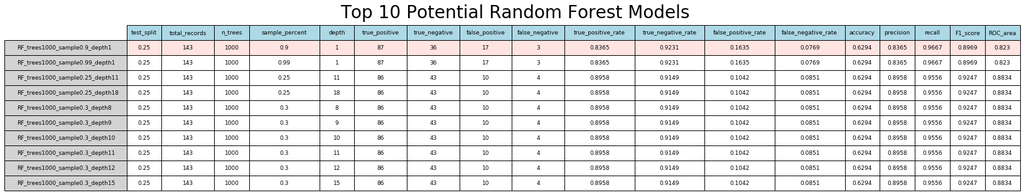

```python
# Select Top 10 Potential Models and Build Table

results_df_test_sort_order = ['false_negative_rate',
                              'true_positive_rate',
                              'true_negative_rate',
                              'false_positive_rate']

results_df_test_ascending_order = [True, False, False, True]

results_df_test.sort_values(by=results_df_test_sort_order,
                            axis=0,
                            ascending=results_df_test_ascending_order,
                            inplace=True)

results_df_test.index = range(len(results_df_test))

table_columns = [#'model_name',
                 #'train_test',
                 'test_split',
                 'total_records',
                 'n_trees',
                 'sample_percent',
                 'depth',
                 'true_positive',
                 'true_negative',
                 'false_positive',
                 'false_negative',
                 'true_positive_rate',
                 'true_negative_rate',
                 'false_positive_rate',
                 'false_negative_rate',
                 'accuracy',
                 'precision',
                 'recall',
                 'F1_score',
                 'ROC_area']

# create potential models table
max_table_rows = 10

potential_models10 = results_df_test.iloc[:max_table_rows,:]
potential_models10.index = range(len(potential_models10))

table_fontsize = 9
column_widths = [.1, .15, .1, .2, .1, .15, .15, .15, .15, .2, .2, .2, .2, .1, .1, .1, .1, .1]
row_labels = potential_models10['model_name'].iloc[:max_table_rows]

cell_colors = [['white' for c in range(len(table_columns))] for r in range(max_table_rows)]
cell_colors[0] = ['mistyrose' for c in range(len(table_columns))]
potential_models10 = potential_models10[table_columns]
potential_models10_table_strings = [list(r) for _,r in potential_models10.astype(str).iterrows()]

# plot potential models table
fig, ax = plt.subplots(figsize=(10,4))
fig.suptitle('Top 10 Potential Random Forest Models', x=1, fontsize=28)
ax.set_axis_off()

model_table = ax.table(potential_models10_table_strings,
                       cellColours=cell_colors,
                       colWidths=column_widths,
                       rowColours=['lightgrey'] * len(potential_models10.columns),
                       rowLabels=row_labels,
                       colColours=['lightblue'] * len(potential_models10.columns),
                       colLabels=table_columns,
                       cellLoc='center',
                       loc='upper left')

model_table.scale(1,2)
model_table.auto_set_font_size(False)
model_table.set_fontsize(table_fontsize)

plt.show()

# select optimal model
optimal_model_name = results_df_test.iloc[0,0]
optimal_model_results = pd.DataFrame([results_df_test.iloc[0,:]])
```

```python
results_df_test.head()
```

|  | model_name | train_test | test_split | total_records | n_trees | sample_percent | depth | true_positive | true_negative | false_positive | false_negative | true_positive_rate | true_negative_rate | false_positive_rate | false_negative_rate | accuracy | precision | recall | F1_score | ROC_area |
| --- | --- | --- | --- | --- | --- | --- | --- | --- | --- | --- | --- | --- | --- | --- | --- | --- | --- | --- | --- | --- |
| 0 | RF_trees1000_sample0.9_depth1 | Test | 0.25 | 143 | 1000 | 0.90 | 1 | 87 | 36 | 17 | 3 | 0.8365 | 0.9231 | 0.1635 | 0.0769 | 0.6294 | 0.8365 | 0.9667 | 0.8969 | 0.8230 |
| 1 | RF_trees1000_sample0.99_depth1 | Test | 0.25 | 143 | 1000 | 0.99 | 1 | 87 | 36 | 17 | 3 | 0.8365 | 0.9231 | 0.1635 | 0.0769 | 0.6294 | 0.8365 | 0.9667 | 0.8969 | 0.8230 |
| 2 | RF_trees1000_sample0.25_depth11 | Test | 0.25 | 143 | 1000 | 0.25 | 11 | 86 | 43 | 10 | 4 | 0.8958 | 0.9149 | 0.1042 | 0.0851 | 0.6294 | 0.8958 | 0.9556 | 0.9247 | 0.8834 |
| 3 | RF_trees1000_sample0.25_depth18 | Test | 0.25 | 143 | 1000 | 0.25 | 18 | 86 | 43 | 10 | 4 | 0.8958 | 0.9149 | 0.1042 | 0.0851 | 0.6294 | 0.8958 | 0.9556 | 0.9247 | 0.8834 |
| 4 | RF_trees1000_sample0.3_depth8 | Test | 0.25 | 143 | 1000 | 0.30 | 8 | 86 | 43 | 10 | 4 | 0.8958 | 0.9149 | 0.1042 | 0.0851 | 0.6294 | 0.8958 | 0.9556 | 0.9247 | 0.8834 |

The optimal model is taking a 90% bootstrap sample and it is only creating a 1-level tree

This code automatically takes the most optimal model, but there is a pattern here where the depth-1 models (with high sample percentages) perform well with predicting negative classes but poorly at positive classes

Two of this type of model (low depth, high sample) perform at the top of all models. They are underfitting the training data, but manage to do better than other top models (high depth, low sample). If we put more work into this, we could probably tune/engineer a complex model that would outperform these low complexity models. This would be absolutely necessary for using machine learning for medical diagnoses, but a lower complexity model could be better in another application where a high data velocity system needed machine learning that was efficent on compute resources

The models that would be best for this are going to be the deeper trees that are using a smaller bootstrap sample

This would work better with more data and deep learning obviously

```python
# Select Optimal Model and Visualize Tree

# retrain optimal model
rf = RandomForestClassifier(n_estimators=optimal_model_results.iloc[0,4],
                            max_depth=optimal_model_results.iloc[0,6],
                            bootstrap=True,
                            max_samples=optimal_model_results.iloc[0,5])



x = pca_output_train
y = y_train.iloc[:,0]

optimal_model = rf.fit(x, y)

estimator_num = 214

tree_visualization = dtreeviz(optimal_model.estimators_[estimator_num],
                              x_data=x,
                              y_data=y,
                              target_name='Predict',
                              feature_names=pca_columns,
                              class_names=['Benign', 'Malignant'],
                              title=f'Selected Estimator from Optimal Random Forest [{estimator_num}:10,000]')

# show tree
tree_visualization.view()
```

I'm going to do K-Folds validation here, I only have enough data for ~4 folds

|  | patient_ID | train_test | predict | target |
| --- | --- | --- | --- | --- |
| 0 | 842302 | Train | 1 | 1 |
| 1 | 842517 | Test | 1 | 1 |
| 2 | 84300903 | Train | 1 | 1 |
| 3 | 84348301 | Train | 1 | 1 |
| 4 | 84358402 | Test | 0 | 1 |
| ... | ... | ... | ... | ... |
| 95 | 86208 | Train | 1 | 1 |
| 96 | 86211 | Test | 0 | 0 |
| 97 | 862261 | Train | 0 | 0 |
| 98 | 862485 | Train | 0 | 0 |
| 99 | 862548 | Train | 1 | 1 |

100 rows × 4 columns

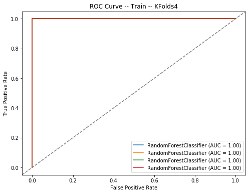

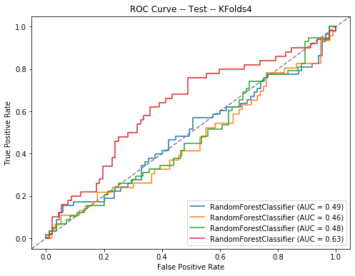

```python
# Conduct K-Folds Validation of Optimal Model Hyperparameters

n_splits = 4

results_df_columns = ['KFold',
                      'n_splits',
                      'model_name',
                      'train_test',
                      'test_split',
                      'total_records',
                      'n_trees',
                      'sample_percent',
                      'depth',
                      'true_positive',
                      'true_negative',
                      'false_positive',
                      'false_negative',
                      'true_positive_rate',
                      'true_negative_rate',
                      'false_positive_rate',
                      'false_negative_rate',
                      'accuracy',
                      'precision',
                      'recall',
                      'F1_score',
                      'ROC_area']

# Create dataframe to store train/test results
results_df = pd.DataFrame(columns=results_df_columns)

# create ROC curve training fix, ax
fig_train, ax_train = plt.subplots(figsize=(8,6))
ax_train.plot([0, 1], [0, 1], transform=ax_train.transAxes, color='grey', ls='--')
ax_train.set_title(f'ROC Curve -- Train -- KFolds{n_splits}')

# create ROC curve testing fix, ax
fig_test, ax_test = plt.subplots(figsize=(8,6))
ax_test.plot([0, 1], [0, 1], transform=ax_test.transAxes, color='grey', ls='--')
ax_test.set_title(f'ROC Curve -- Test -- KFolds{n_splits}')

# assign x, y
x = pca_output
y = target

# split by K-Folds
kf = KFold(n_splits=n_splits, random_state=375, shuffle=True)

kf_counter = 0

# conduct K-Folds validation
for train_index, test_index in kf.split(pca_output):

    # split dataset
    x_train = x.filter(train_index, axis=0)
    x_test = x.filter(test_index, axis=0)
    y_train = y.filter(train_index, axis=0)
    y_test = y.filter(test_index, axis=0)
    patient_IDs_train = patient_IDs.filter(train_index, axis=0)
    patient_IDs_test = patient_IDs.filter(test_index, axis=0)

    # train model
    train_test = 'Train'

    rf = RandomForestClassifier(n_estimators=n_trees,
                                max_depth=depth,
                                bootstrap=True,
                                max_samples=samples)

    rf_model = rf.fit(x_train, y_train)
    rf_train_predict = pd.DataFrame(rf.predict(x_train), index=x_train.index, columns=['predict'])

    # get train partition results
    confusion_matrix_train = metrics.confusion_matrix(rf_train_predict, y_train)

    total_records = len(x_train)

    true_positive = confusion_matrix_train[0,0]
    true_negative = confusion_matrix_train[1,1]
    false_positive = confusion_matrix_train[0,1]
    false_negative = confusion_matrix_train[1,0]

    true_positive_rate = np.round(true_positive / (true_positive + false_positive), decimals)
    true_negative_rate = np.round(true_negative / (true_negative + false_negative), decimals)
    false_positive_rate = np.round(false_positive / (true_positive + false_positive), decimals)
    false_negative_rate = np.round(false_negative / (true_negative + false_negative), decimals)

    accuracy = np.round((true_positive + false_negative) / total_records, decimals)
    precision = np.round(true_positive / (true_positive + false_positive), decimals)
    recall = np.round(true_positive / (true_positive + false_negative), decimals)
    F1_score = np.round(2 / ((1 / precision) + (1 / recall)), decimals)

    ROC_area = np.round(metrics.roc_auc_score(y_train, rf_train_predict), decimals)

    # plot training ROC curve
    metrics.plot_roc_curve(rf_model,
                           x_train,
                           y_train,
                           ax=ax_train)

    # save model training results
    results_df_tmp = pd.DataFrame([[kf_counter,
                                    n_splits,
                                    optimal_model_name,
                                    train_test,
                                    test_split,
                                    total_records,
                                    n_trees,
                                    samples,
                                    depth,
                                    true_positive,
                                    true_negative,
                                    false_positive,
                                    false_negative,
                                    true_positive_rate,
                                    true_negative_rate,
                                    false_positive_rate,
                                    false_negative_rate,
                                    accuracy,
                                    precision,
                                    recall,
                                    F1_score,
                                    ROC_area]], columns=results_df_columns)

    results_df = pd.concat([results_df, results_df_tmp], axis=0)

    # test model
    train_test = 'Test'

    rf_test_predict = pd.DataFrame(rf.predict(x_test), index=x_test.index, columns=['predict'])

    # get test partition results
    confusion_matrix_test = metrics.confusion_matrix(rf_test_predict, y_test)

    total_records = len(x_test)

    true_positive = confusion_matrix_test[0,0]
    true_negative = confusion_matrix_test[1,1]
    false_positive = confusion_matrix_test[0,1]
    false_negative = confusion_matrix_test[1,0]

    true_positive_rate = np.round(true_positive / (true_positive + false_positive), decimals)
    true_negative_rate = np.round(true_negative / (true_negative + false_negative), decimals)
    false_positive_rate = np.round(false_positive / (true_positive + false_positive), decimals)
    false_negative_rate = np.round(false_negative / (true_negative + false_negative), decimals)

    accuracy = np.round((true_positive + false_negative) / total_records, decimals)
    precision = np.round(true_positive / (true_positive + false_positive), decimals)
    recall = np.round(true_positive / (true_positive + false_negative), decimals)
    F1_score = np.round(2 / ((1 / precision) + (1 / recall)), decimals)

    ROC_area = np.round(metrics.roc_auc_score(y_test, rf_test_predict), decimals)

    # plot testing ROC curve
    metrics.plot_roc_curve(rf_model,
                           x_test,
                           y_test,
                           ax=ax_test)

    # save model testing results
    results_df_tmp = pd.DataFrame([[kf_counter,
                                    n_splits,
                                    optimal_model_name,
                                    train_test,
                                    test_split,
                                    total_records,
                                    n_trees,
                                    samples,
                                    depth,
                                    true_positive,
                                    true_negative,
                                    false_positive,
                                    false_negative,
                                    true_positive_rate,
                                    true_negative_rate,
                                    false_positive_rate,
                                    false_negative_rate,
                                    accuracy,
                                    precision,
                                    recall,
                                    F1_score,
                                    ROC_area]], columns=results_df_columns)

    results_df = pd.concat([results_df, results_df_tmp], axis=0)

    # concatenate model validation data and results
    train_list = ['Train' for t in range(len(patient_IDs_train))]
    train_series = pd.Series(train_list, index=x_train.index, name='train_test')

    train_df = pd.concat([patient_IDs_train,
                          train_series,
                          rf_train_predict,
                          y_train], axis=1)


    test_list = ['Test' for t in range(len(patient_IDs_test))]
    test_series = pd.Series(test_list, index=x_test.index, name='train_test')

    test_df = pd.concat([patient_IDs_test,
                         test_series,
                         rf_test_predict,
                         y_test], axis=1)

    output_df = pd.concat([train_df, test_df], axis=0).sort_index()

    kf_counter += 1


results_df.index = range(len(results_df))

output_df.head(100)
```

Thank you for reviewing my work. The validation results indicate that this strategy is not working great. This problem probably requires deep learning